# Stratification and Aggregation Validation

Adam A. Kemberling

2021-04-07

# About

## Starting Data

```r
####__  Data  ####


# Update, newer Data 03/19/2021:
load(paste0(nmfs_path, "2021_survdat/NEFSC_BTS_all_seasons_03032021.RData"))
trawldat <- survey$survdat %>% clean_names() %>%
  rename(est_year = year)

rm(survey)


# And filter years
trawldat <- filter(trawldat, est_year >= 2006 & est_year <= 2010) %>%
  mutate(comname = tolower(comname))
```

## Clean up Function

The size spectra clean up function does any data prep including:

- Removal of incomplete records
- Spatial filters
- Pairing species to growth coefficients
- Calculating stratum effort and area weighting coefficients
- Estimating stratified catch rates

```r
# Cleanup functions
# source(here("R/01_old_nefsc_ss_build.R"))
source(here("R/01_nefsc_ss_build_nodrop.R"))

# Clean/Prep Survdat 2006-2010
survdat_21 <- survdat_prep_nodrop(survdat = trawldat)

# Add LW coefficients
# cutoff species from:
survdat_lw <- add_lw_info(survdat_clean = survdat_21)

# # Validation Step:
# # Change total LW weight to ignore numlen_adjusted conversion
# # This will isolate whether the coefficients are bad or whether its the adjustment
# survdat_lw$sum_weight_kg <- survdat_lw$ind_weight_kg * survdat_lw$numlen

# Get stratified Biomass
weights_21 <- add_area_stratification(survdat_weights = survdat_lw, include_epu = F)
```

**NOTE:**

The cleanup function retains the station-level information of the raw data, so its possible to compare individual stations across the raw and prepped data:

```r
# test_station <- weights_20$id[1]
test_station <- weights_21$id[1]
test_species <- "haddock"

print(paste0("The test station is: ", test_station))
```

```
[1] "The test station is: 2006103231260"
```

```r
print(paste0("The test species is: ", test_species))
```

```
[1] "The test species is: haddock"
```

# Raw Comparisons

## Are Biomass values repeated?

Confusion has arisen about whether at a station the `survdat$BIOMASS` column should be summed for each species to get total biomass, or whether it is the aggregate biomass for the species and should be pulled once as a unique value.

The following code will compare how either of these compares to what the L-W Biomass is when looking at the number at length.

As an added check I flagged the number of length classes per tow and created a new column that is the bulk biomass divided by that number. This implementation lets me add those values just as I would for the L-W mass for aggregations. This value was added to the plot to verify that there weren’t instances where they diverged.

```r
important_species <- c("atlantic cod", "haddock", "spiny dogfish", "pollock")
focal_species <- weights_21 %>% filter(comname %in% important_species)

# Biomass treated as the total biomass for that species, pulled once for each tow
biomass_as_total <- focal_species %>%
  distinct(est_year,id, comname, catchsex, biom_adj) %>%
  group_by(est_year, comname) %>%
  summarise(`Biomass as Bulk Total` = sum(biom_adj),
            .groups = "keep")


# Biomass treated as a total divided evenly among the number of length classes
biomass_spread_out  <- focal_species %>%
  # Sum up for each station for each sex
  group_by(est_year, comname, id, catchsex) %>%
  summarise(biom_adj = sum(biom_adj),
            biomass_divided = sum(biom_per_lclass),
            sum_weight_kg = sum(sum_weight_kg)) %>%
  # Aggregate again for the years
  group_by(est_year, comname) %>%
  summarise(`Biomass Divided Among Length Classes` = sum(biom_adj),
            `Biomass Readjusted for n Length Classes` = sum(biomass_divided),
            `Length Weight Biomass Total` = sum(sum_weight_kg))
```

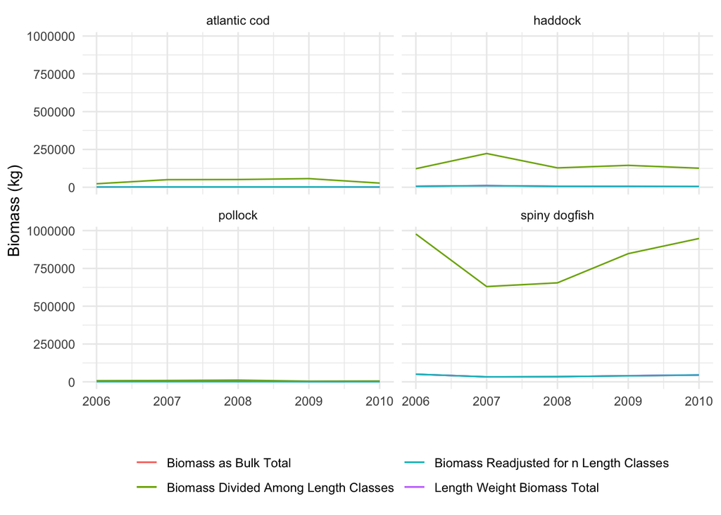

```r
# Plotting different ways to treat biomass
ggplot() +
  geom_line(data = biomass_as_total,
            aes(est_year, `Biomass as Bulk Total`,
                color = "Biomass as Bulk Total")) +
  geom_line(data = biomass_spread_out,
            aes(est_year, `Biomass Divided Among Length Classes`,
                color = "Biomass Divided Among Length Classes")) +
  geom_line(data = biomass_spread_out,
            aes(est_year, `Length Weight Biomass Total`,
                color = "Length Weight Biomass Total")) +
  geom_line(data = biomass_spread_out,
            aes(est_year, `Biomass Readjusted for n Length Classes`,
                color = "Biomass Readjusted for n Length Classes")) +
  labs(x = "", y = "Biomass (kg)", color = "") +
  facet_wrap(~comname) +
  theme(legend.position = "bottom") +
  guides(color = guide_legend(ncol = 2))
```

## Total Biomass vs. L-W Biomass

Due to subsampling of large catches and inherent variability around the mean weight at length for a species we expect the biomass estimates to resemble but not exactly match the biomass recorded for a species total weight at a station. The following figures aim to track how these aggregate totals compare over the years of the survey.

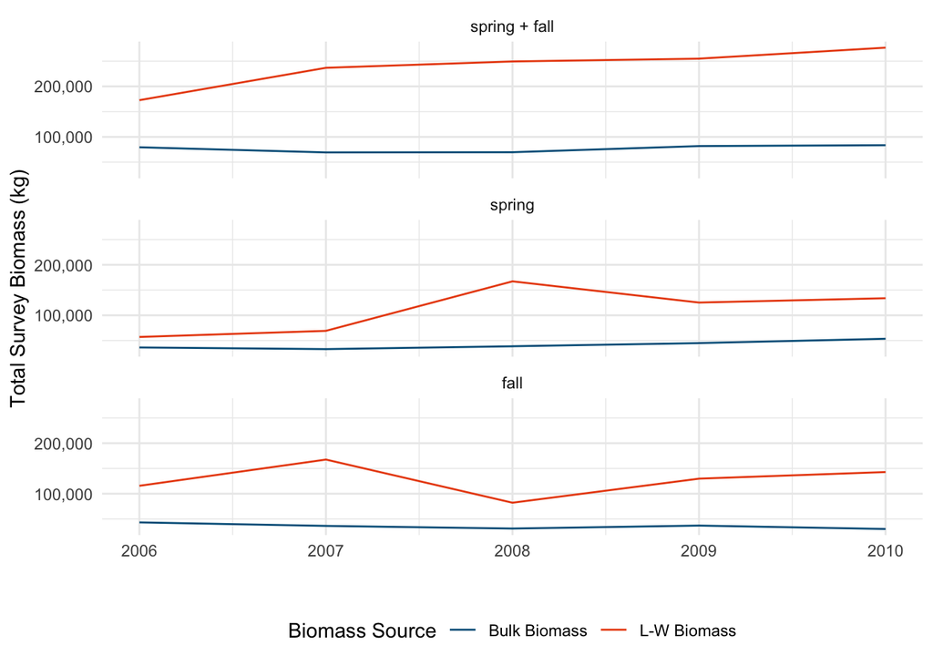

```r
####  Annual Summary, summer and fall  ####

#BIOMASS
# Because we are taking distinct records for BIOMASS
# we use biom_adj not per_lclass
ann_summ_bio <- weights_21 %>%
  distinct(est_year, id, comname, catchsex, biom_adj, biom_per_lclass, expanded_biom_s) %>%
  group_by(est_year) %>%
  summarise(`Bulk Biomass` = sum(biom_adj),
            `Area Stratified Total BIOMASS` = sum(expanded_biom_s),
            season = "spring + fall")


# L-W
ann_summ_lw <- weights_21 %>%
  distinct(est_year, id, comname, length, catchsex, biom_adj,
           biom_per_lclass, expanded_biom_s, sum_weight_kg,
           expanded_lwbio_s) %>%
  group_by(est_year) %>%
  summarise(`L-W Biomass` = sum(sum_weight_kg),
            `Area Stratified Total L-W` = sum(expanded_lwbio_s),
            season = "spring + fall")

# Join them
ann_summs <- left_join(ann_summ_bio, ann_summ_lw)



####  Annual Summary, separate seasons  ####

#BIOMASS
seas_summ_bio <-  weights_21  %>%
  distinct(est_year, season, id, comname, catchsex, biom_adj, biom_per_lclass, expanded_biom_s) %>%
  group_by(est_year, season) %>%
  summarise(`Bulk Biomass` = sum(biom_adj),
            `Area Stratified Total BIOMASS` = sum(expanded_biom_s))
# L-W
seas_summ_lw <- weights_21%>%
  group_by(est_year, season) %>%
  summarise(`L-W Biomass` = sum(sum_weight_kg),
            `Area Stratified Total L-W` = sum(expanded_lwbio_s))

# Join them
seas_summs <- left_join(seas_summ_bio, seas_summ_lw, by = c("est_year", "season"))


# reformat for plotting
summaries_long <- bind_rows(ann_summs, seas_summs) %>%
  pivot_longer(names_to = "Biomass Source",
               values_to = "Total Survey Biomass (kg)",
               cols = c(`L-W Biomass`, `Bulk Biomass`)) %>%
  pivot_longer(names_to = "Stratified Biomass Source",
               values_to = "Area Projected Biomass (kg)",
               cols = c(`Area Stratified Total L-W`,`Area Stratified Total BIOMASS`)) %>%
  mutate(season = factor(season, levels = c("spring + fall", "spring", "fall")))


# Total Biomass from survey
ggplot(summaries_long, aes(est_year, `Total Survey Biomass (kg)`, color = `Biomass Source`)) +
  geom_line() +
  facet_wrap(~season, ncol = 1) +
  scale_y_continuous(labels = comma_format())+
  scale_color_gmri() +
  labs(x = "") +
  theme(legend.position = "bottom")
```

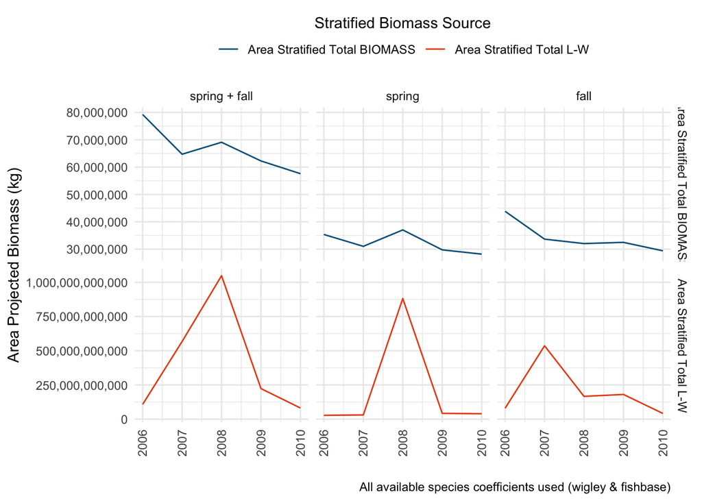

```r
# What that biomass is extended out to total areas
ggplot(summaries_long, aes(est_year, `Area Projected Biomass (kg)`, color = `Stratified Biomass Source`)) +
  geom_line() +
  facet_grid(`Stratified Biomass Source`~season, scales = "free") +
  scale_y_continuous(labels = comma_format())+
  scale_color_gmri() +
  labs(x = "",
       caption = "All available species coefficients used (wigley & fishbase)") +
  theme(legend.position = "top",
        axis.text.x = element_text(angle = 90, vjust = 0.5)) +
  guides(color = guide_legend(title.position = "top", title.hjust = 0.5))
```

# Aggregation Comparisons

Another comparison of interest is whether it makes a difference to calculate catch rates for individual lengths of a species, expanding those rates out to get a stratified biomass. Or to aggregate before estimating catch rates.

The following code will look into that comparison.

## Size Specific Catch Rates

The way the size spectra build code is written catch rates for each length caught are estimated and weighted for every stratum in which they are caught. Weighting is adjusted by the amount of effort within that stratum in that year, and the relative size of the stratum to the overall sampling coverage that year.

```r
weights_21 %>%
    filter(id == test_station,
           comname == test_species) %>%
      select("Species"                                      = comname,
             "Length"                                       = length,
             "Number at Length"                             = numlen_adj,
             "Weight (g)"                                   = sum_weight_kg,
             "Stratum"                                      = stratum,
             "Tows in Stratum (by year)"                    = strat_ntows,
             "Abundance per Tow"                            = abund_tow_s,
             "Weighted Abundance per Tow (by stratum area)" = wt_abund_s,
             "Projected Abundance (stratum)"                = expanded_abund_s) %>%
  mutate(`Weight (g)` = `Weight (g)` * 1000) %>%
  mutate_if(is.numeric, round, 3) %>%
  head(10) %>%
  kable() %>%
  kable_styling(font_size = 10, )
```

| Species | Length | Number at Length | Weight (g) | Stratum | Tows in Stratum (by year) | Abundance per Tow | Weighted Abundance per Tow (by stratum area) | Projected Abundance (stratum) |
| --- | --- | --- | --- | --- | --- | --- | --- | --- |
| haddock | 39 | 1 | 609.516 | 1260 | 15 | 0.067 | 0.001 | 5173 |
| haddock | 41 | 1 | 711.330 | 1260 | 15 | 0.067 | 0.001 | 5173 |
| haddock | 42 | 1 | 766.297 | 1260 | 15 | 0.067 | 0.001 | 5173 |
| haddock | 43 | 1 | 824.066 | 1260 | 15 | 0.067 | 0.001 | 5173 |
| haddock | 44 | 1 | 884.710 | 1260 | 15 | 0.067 | 0.001 | 5173 |
| haddock | 50 | 1 | 1313.055 | 1260 | 15 | 0.067 | 0.001 | 5173 |
| haddock | 52 | 2 | 2964.323 | 1260 | 15 | 0.133 | 0.002 | 10346 |

The question is whether the sum of these “Projected Abundances” is the same when these catch rates are done in aggregate using the following function:

```r
agg_species_metrics
```

```
function (.data = data, ..., include_epu = FALSE)
{
    num_tows <- .data %>% group_by(...) %>% summarise(n_stations = n_distinct(id),
        n_species = n_distinct(comname), .groups = "keep")
    data_stratified <- .data %>% left_join(num_tows)
    species_data_stratified <- data_stratified %>% group_by(...,
        comname) %>% summarise(n_tows = max(n_stations), n_species = max(n_species),
        lw_biomass_kg = sum(sum_weight_kg), fscs_biomass_kg = sum(biom_per_lclass),
        abundance = sum(numlen_adj), abund_tow = abundance/n_tows,
        lwbio_tow = lw_biomass_kg/n_tows, biom_tow = fscs_biomass_kg/n_tows,
        mean_ind_length = weighted.mean(length, numlen_adj),
        mean_ind_bodymass_lw = weighted.mean(ind_weight_kg, numlen_adj),
        mean_ind_length_lw = weighted.mean(length, numlen_adj),
        strat_abundance_s = sum(expanded_abund_s), lw_strat_biomass_s = sum(expanded_lwbio_s,
            na.rm = T), fscs_strat_biomass_s = sum(expanded_biom_s),
        .groups = "keep") %>% ungroup()
    if (include_epu == T) {
        epu_strat <- data_stratified %>% group_by(..., comname) %>%
            summarise(strat_abundance_epu = sum(expanded_abund_epu),
                lw_strat_biomass_epu = sum(expanded_lwbio_epu,
                  na.rm = T), fscs_strat_biomass_epu = sum(expanded_biom_epu),
                .groups = "keep") %>% ungroup()
        species_data_stratified <- bind_cols(species_data_stratified,
            epu_strat)
    }
    return(species_data_stratified)
}
```

### Aggregate After

```r
cod_21 <- weights_21 %>% filter(comname == "atlantic cod")

# adding up stratified weights at the end
cod_21 %>%
  group_by(est_year, season, comname) %>%
  summarise(stratified_abundance = sum(expanded_abund_s),
            stratified_lwbio     = sum(expanded_lwbio_s),
            stratified_biom      = sum(expanded_biom_s)) %>%
  select(Year                     = est_year,
         Season                   = season,
         Species                  = comname,
         `Stratified Abundance`   = stratified_abundance,
         `Stratified LWbio`       = stratified_lwbio,
         `Stratified Biom`        = stratified_biom) %>%
  kable() %>%
  kable_styling(font_size = 10)
```

| Year | Season | Species | Stratified Abundance | Stratified LWbio | Stratified Biom |
| --- | --- | --- | --- | --- | --- |
| 2006 | fall | atlantic cod | 3651308 | 7985681 | 5126766 |
| 2006 | spring | atlantic cod | 2580640 | 7940825 | 4566881 |
| 2007 | fall | atlantic cod | 2080920 | 3974246 | 3136783 |
| 2007 | spring | atlantic cod | 9676796 | 145812093 | 12237292 |
| 2008 | fall | atlantic cod | 5032742 | 10933766 | 5709765 |
| 2008 | spring | atlantic cod | 7834853 | 95155645 | 10309265 |
| 2009 | fall | atlantic cod | 4704314 | 21049201 | 5326912 |
| 2009 | spring | atlantic cod | 5849792 | 36110369 | 8869505 |
| 2010 | fall | atlantic cod | 2215407 | 4156583 | 2811971 |
| 2010 | spring | atlantic cod | 7751434 | 41413234 | 8715718 |

### Aggregate First

```r
# Aggregating then calculating the catch rates etc.
cod_21 %>%
  agg_species_metrics(est_year, season) %>%
  select(Year                     = est_year,
         Season                   = season,
         Species                  = comname,
         `Stratified Abundance`   = strat_abundance_s,
         `Stratified LWbio`       = lw_strat_biomass_s,
         `Stratified Biom`        = fscs_strat_biomass_s) %>%
  kable() %>%
  kable_styling(font_size = 10)
```

| Year | Season | Species | Stratified Abundance | Stratified LWbio | Stratified Biom |
| --- | --- | --- | --- | --- | --- |
| 2006 | fall | atlantic cod | 3651308 | 7985681 | 5126766 |
| 2006 | spring | atlantic cod | 2580640 | 7940825 | 4566881 |
| 2007 | fall | atlantic cod | 2080920 | 3974246 | 3136783 |
| 2007 | spring | atlantic cod | 9676796 | 145812093 | 12237292 |
| 2008 | fall | atlantic cod | 5032742 | 10933766 | 5709765 |
| 2008 | spring | atlantic cod | 7834853 | 95155645 | 10309265 |
| 2009 | fall | atlantic cod | 4704314 | 21049201 | 5326912 |
| 2009 | spring | atlantic cod | 5849792 | 36110369 | 8869505 |
| 2010 | fall | atlantic cod | 2215407 | 4156583 | 2811971 |
| 2010 | spring | atlantic cod | 7751434 | 41413234 | 8715718 |

# LW Coefficient Comparisons

Looks like the root cause is just the difference between what the mean prediction from species-specific coefficients is when compared to the biomass column in survdat.

If we take the totals from the length-weight derived biomasses and the BIOMASS columns that match we can rank them by how often they over/underestimate biomass.

```r
# Load all years and species using most recent data
weights_all <- survdat_prep_nodrop(survdat_source = "most recent") %>%
  add_lw_info(cutoff = FALSE) %>%
  add_area_stratification()
```

**Summary and Plotting Functions**

```r
# Get the total weights for each station, then do it each year for every species
mismatch_ranks <- function(x){
  species_summaries <- x %>%
    group_by(est_year, comname, id) %>%
    summarise(number_caught = sum(numlen_adj),
              length_weight_biomass = sum(sum_weight_kg),
              ship_measured_biomass = sum(biom_per_lclass),
              lw_underestimate = ship_measured_biomass - length_weight_biomass,
              .groups = "keep") %>%
    ungroup()


  # Format rankings to plot
  n_species <- length(unique(species_summaries$comname))
  ranks <- species_summaries %>%
    mutate(comname = fct_reorder(.f = comname, .x = lw_underestimate, mean),
           species_rank = as.numeric(comname),
           extremes = ifelse( species_rank >= n_species - 20, "Extreme Under-Estimation", NA),
           extremes = ifelse(species_rank <= 20, "Extreme Over-Estimation", extremes))

  return(ranks)

}


# Plot flags top and bottom 15 species that don't match well with survdat$biomass
mismatch_plot <- function(x){
  # All ranks in one panel
  all_ranks <- x %>%
    ggplot(aes(lw_underestimate, species_rank)) +
      geom_boxplot(aes(group = species_rank), color = "gray40") +
      geom_boxplot(data = filter(x, is.na(extremes) == FALSE),
                   aes(group = species_rank, color = extremes)) +
      geom_vline(xintercept = 0, size = 0.5, color = "black", linetype = 2) +
      scale_x_continuous(labels = comma_format()) +
      scale_color_gmri() +
      guides("color" = guide_legend(title = "")) +
      labs(x = "Underestimation of Biomass from LW Regressions\nShipboard Weight - LW Biomass (kg)",
           y = "Underestimation Rank") +
    theme(legend.position = c(0.2, 1))

  # Focus on top 5
  top_5 <- x %>%
    filter(extremes == "Extreme Under-Estimation") %>%
    ggplot(aes(lw_underestimate, comname)) +
      geom_boxplot(aes(group = species_rank), color = gmri_cols("orange")) +
      scale_color_gmri() +
      scale_x_continuous(labels = comma_format()) +
      labs(x = "",
           y = "",
           subtitle = "L-W mass < 'survdat$Biomass'") +
    theme(title = element_text(hjust = 0.5))

  # Focus on bottom 5
  bot_5 <- x %>%
    filter(extremes == "Extreme Over-Estimation") %>%
    ggplot(aes(lw_underestimate, comname)) +
      geom_boxplot(aes(group = species_rank), color = gmri_cols("gmri blue")) +
      scale_color_gmri() +
      scale_x_continuous(labels = comma_format()) +
      labs(x = "Underestimation of Biomass from LW Regressions\nShipboard Weight - LW Biomass (kg)",
           y = "",
           subtitle = "L-W mass > 'survdat$Biomass'") +
    theme(title = element_text(hjust = 0.5))



  # Patchwork plot
  plot_out <- all_ranks | (top_5/bot_5)
  return(plot_out)
}
```

## Wigley 06 - Species

These species got a priority pass when matching with L-W coefficients because they are from a more recent and region specific source.

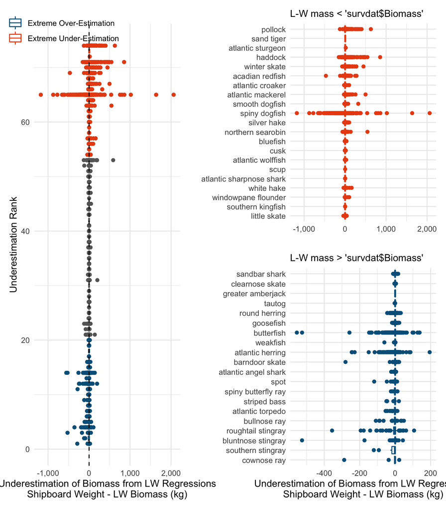

```r
# Get ranks for everything
all_source_ranks <- weights_21 %>%
  mismatch_ranks()

# Just Wigley
wigley_ranks <- weights_all %>% filter(source == "wigley") %>%
  mismatch_ranks()

# Wigley mismatch plot
wigley_ranks %>%
  mismatch_plot()
```

## Fishbase Species

These species were matched up with coefficients from fishbase and are likely less accurate than the ones with svspp codes.

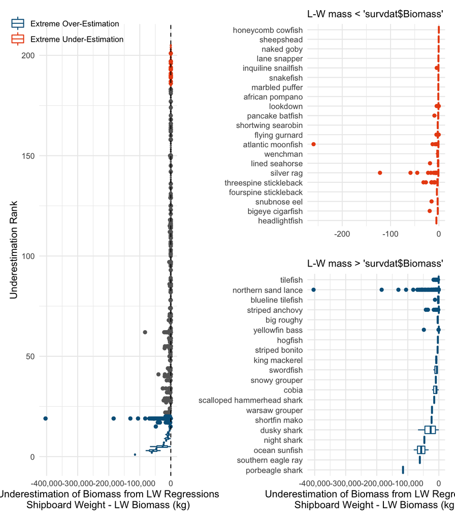

```r
fishbase_ranks <- weights_all %>% filter(source == "fishbase") %>%
  mismatch_ranks()

fishbase_ranks %>%
  mismatch_plot()
```

# LW Regression Fit Diagnostics

The following tabs are an attempt to dig into what is happening with species on the extremes of the previous plots.

## Subsampling Errors

Take the species that stood out above and plot the mismatch versus the station abundances. This should highlight whether its an issue of sub-sampling. Might be beneficial to split it for seasons for dogfish and some other species.

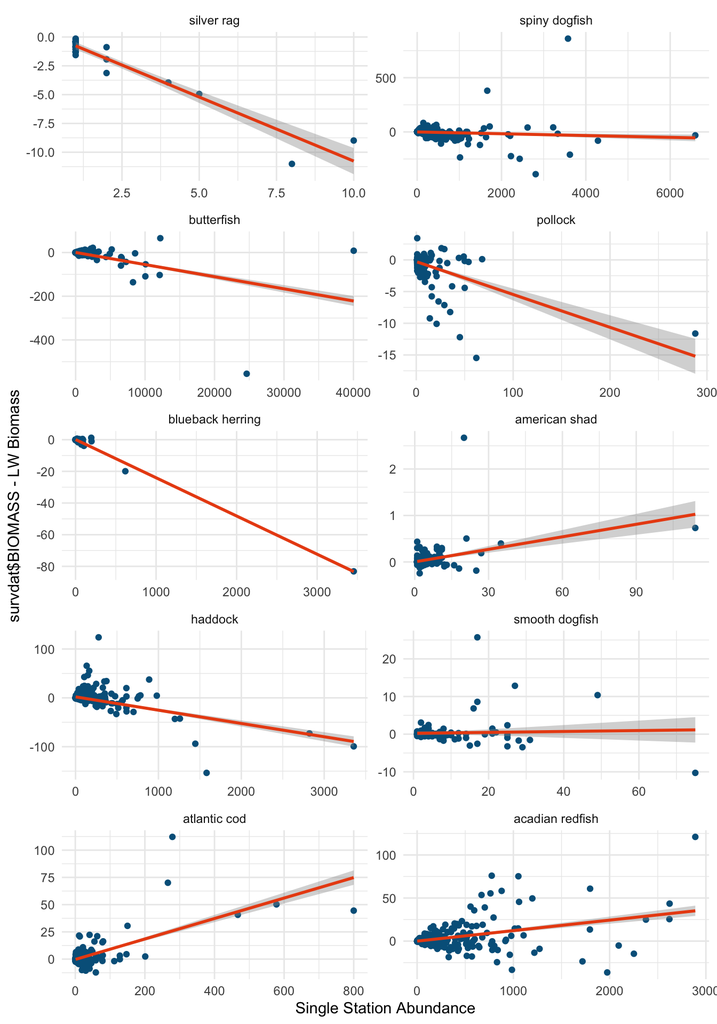

```r
#species that are caught in large numbers
subsampling_suspects <- c("spiny dogfish", "haddock", "blueback herring",
                          "american shad", "windowpane", "silver rag", "atlantic cod",
                          "pollock", "smooth dogfish", "acadian redfish", "butterfish")



# plot
all_source_ranks %>%
  filter(comname %in% subsampling_suspects) %>%
  ggplot(aes(number_caught, lw_underestimate)) +
      geom_point(color = gmri_cols("gmri blue")) +
      geom_smooth(formula = y ~ x, method = "lm", color = gmri_cols("orange")) +
      facet_wrap(~comname, scales = "free", ncol = 2) +
      labs(x = "Single Station Abundance", y = "survdat$BIOMASS - LW Biomass")
```

## Mismatch Outliers

Dig into the cases where things are really off by flagging the outliers and plotting those relationships.

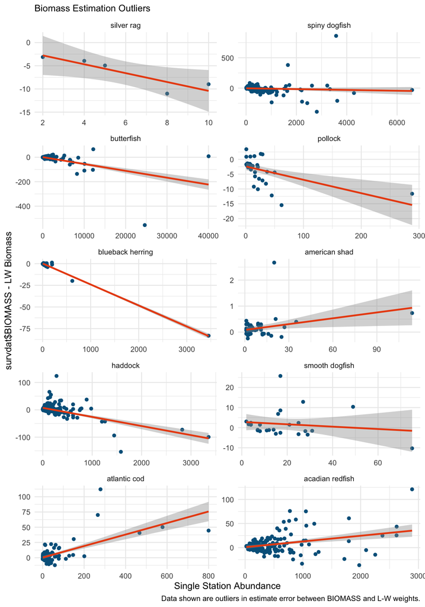

```r
#### Outlier Rules ####


#Z-score
isnt_out_z <- function(x, thres = 3, na.rm = TRUE) {
  abs(x - mean(x, na.rm = na.rm)) <= thres * sd(x, na.rm = na.rm)}

# Median Absolute Deviation https://en.wikipedia.org/wiki/Median_absolute_deviation
isnt_out_mad <- function(x, thres = 3, na.rm = TRUE) {
  abs(x - median(x, na.rm = na.rm)) <= thres * mad(x, na.rm = na.rm)}


# Tukeys Fences - box plot outliers https://en.wikipedia.org/wiki/Outlier#Tukey&%2339;s_fences
isnt_out_tukey <- function(x, k = 1.5, na.rm = TRUE) {
  quar <- quantile(x, probs = c(0.25, 0.75), na.rm = na.rm)
  iqr <- diff(quar)

  (quar[1] - k * iqr <= x) & (x <= quar[2] + k * iqr)}

# Mahalanobis Distance https://en.wikipedia.org/wiki/Mahalanobis_distance
maha_dist <- . %>% select_if(is.numeric) %>%
    mahalanobis(center = colMeans(.), cov = cov(.))
isnt_out_maha <- function(tbl, isnt_out_f, ...) {
  tbl %>% maha_dist() %>% isnt_out_f(...)}

# Definition of non-outlier row
isnt_out_funs <- list(
  z = isnt_out_z,
  mad = isnt_out_mad,
  tukey = isnt_out_tukey)

#Implementation
all_source_ranks <- all_source_ranks %>%
  split(.$comname) %>%
  map_dfr(~ .x %>%
  mutate(abundance_outliers = isnt_out_tukey(number_caught),
         estimation_outliers = isnt_out_tukey(lw_underestimate)))




# Plot the estimation outliers
# Filter to just outliers for mismatches between BIOMASS and lw bio
all_source_ranks %>%
  filter(estimation_outliers == F,
         comname %in% subsampling_suspects)%>%
  ggplot(aes(number_caught, lw_underestimate)) +
      geom_point(color = gmri_cols("gmri blue")) +
      geom_smooth(formula = y ~ x, method = "lm",
                  color = gmri_cols("orange")) +
      facet_wrap(~comname, scales = "free", ncol = 2) +
      labs(x = "Single Station Abundance",
           y = "survdat$BIOMASS - LW Biomass",
           subtitle = "Biomass Estimation Outliers",
           caption = "Data shown are outliers in estimate error between BIOMASS and L-W weights.")
```

## Haddock Issues

Haddock is one of the most commonly caught species, particularly true in the recent years. It also **had** a particularly high prevalence for large deviance from the two biomass sources.

Here is how it looks following come corrections to the survdat build.

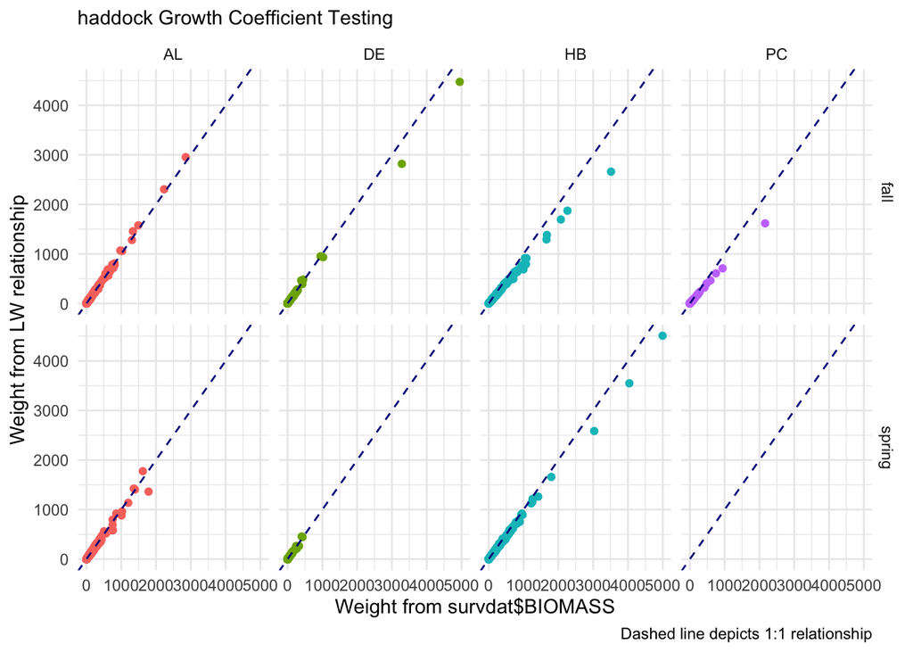

```r
single_species <- "haddock"

# haddock check
haddock <- weights_all %>%
  filter(comname == single_species)


# which coefficients are breaking it
haddock %>%
  group_by(id, est_year, season, svvessel, catchsex, a, b, ln_a) %>%
  summarise(lw_bio = sum(sum_weight_kg),
            biomass_col = sum(biom_per_lclass),
            .groups = "keep") %>%
  ggplot(aes(biomass_col, lw_bio,
             color = svvessel)) +
  geom_point(show.legend = F) +
  facet_grid(season~svvessel) +
  geom_abline(slope = 1, intercept = 0, linetype = 2, color  = "darkblue") +
  labs(x = "Weight from survdat$BIOMASS", y = "Weight from LW relationship",
       caption = "Dashed line depicts 1:1 relationship",
       subtitle = paste0(single_species, " Growth Coefficient Testing") )
```

## Cutoff threshold

If we assume that the total biomass weighed at a station is correct then we can use some cutoff value for an unacceptable deviaiton from the known weight.

For example values 100% heavier or lighter.

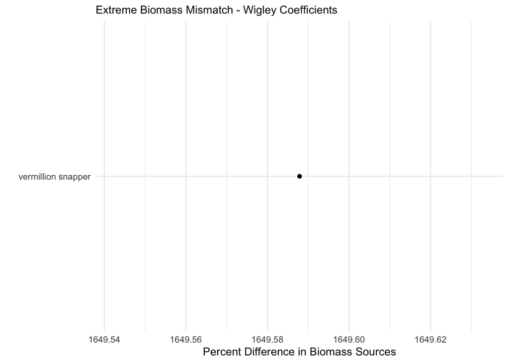

```r
# Identify Coefficients that seem off
perc_differences <- weights_all %>%
  group_by(comname, source) %>%
  summarise(
    `Biomass`    = sum(biom_per_lclass),
    `LW Biomass` = sum(sum_weight_kg),
    weight_perc_diff  = ((`LW Biomass` - Biomass) / Biomass) * 100,
    broken_coef  = ifelse(weight_perc_diff > 100 | weight_perc_diff < -100, "broken", "less broken"),
    .groups = "keep") %>% ungroup()


# Pull the ones that are flagged
broken_coefficients <- perc_differences %>%
  filter(broken_coef == "broken")


# Broken Wigley Coefficientz
broken_coefficients %>%
  filter(source == "wigley") %>%
  mutate(comname = fct_reorder(comname, weight_perc_diff, max)) %>%
  ggplot(aes(weight_perc_diff, comname)) +
   geom_point() +
   labs(x = "Percent Difference in Biomass Sources", y = "",
        subtitle = "Extreme Biomass Mismatch - Wigley Coefficients")
```

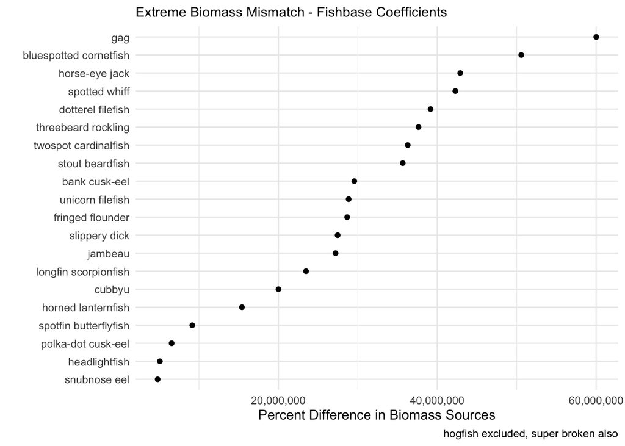

```r
# Broken fishbase coefficients
broken_coefficients %>%
  filter(source == "fishbase",
         comname != "hogfish") %>%
  top_n(n = 20, weight_perc_diff) %>%
  mutate(comname = fct_reorder(comname, weight_perc_diff, max)) %>%
  ggplot(aes(weight_perc_diff, comname)) +
   geom_point() +
   labs(x = "Percent Difference in Biomass Sources",
        y = "",
        caption = "hogfish excluded, super broken also",
        subtitle = "Extreme Biomass Mismatch - Fishbase Coefficients") +
  scale_x_continuous(labels = scales::comma_format())
```

# Removing Bad Fits with Cutoff

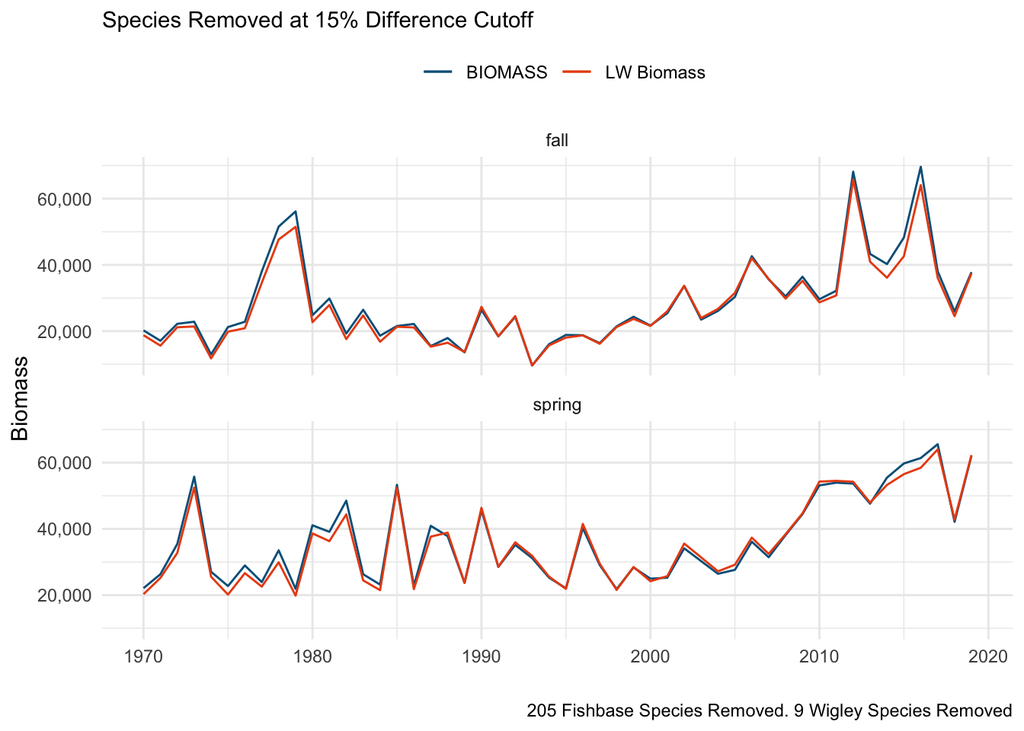

```r
# Cutoff Threshold
cut_percent <- 15

fishbase_cutoffs <- perc_differences %>%
  filter(source == "fishbase",
         weight_perc_diff >= cut_percent) %>%
  pull(comname)

wigley_cutoffs <- perc_differences %>%
  filter(source == "wigley",
         weight_perc_diff >= cut_percent) %>%
  pull(comname)

# concatenate them
bad_coefficients <-
  c( fishbase_cutoffs, wigley_cutoffs)


# drop things using cutoff
fish_removed <- weights_all %>%
  filter(comname %not in% bad_coefficients)


# Re-total weights without those species
new_totals <- fish_removed %>%
 group_by(est_year, season) %>%
 summarise(`Biomass` = sum(biom_per_lclass),
           `LW Biomass` = sum(sum_weight_kg),
           .groups = "keep")


# Plot timelines again
ggplot(new_totals, aes(est_year)) +
  geom_line(aes(y = Biomass, color = "BIOMASS")) +
  geom_line(aes(y = `LW Biomass`, color = "LW Biomass")) +
  facet_wrap(~season, ncol = 1) +
  scale_y_continuous(labels = comma_format())+
  scale_color_gmri() +
  labs(x = "",
       color = "",
       subtitle = paste0("Species Removed at ", cut_percent, "% Difference Cutoff"),
       caption = paste(length(fishbase_cutoffs),"Fishbase Species Removed.",    length(wigley_cutoffs), "Wigley Species Removed")) +
  theme(legend.position = "top")
```

```r
fishbase_okay <- perc_differences %>%
  filter(source == "fishbase",
         weight_perc_diff < cut_percent) %>%
  pull(comname)

wigley_okay <- perc_differences %>%
  filter(source == "wigley",
         weight_perc_diff < cut_percent) %>%
  pull(comname)


wigley_bad <- perc_differences %>%
  filter(source == "wigley",
         weight_perc_diff > cut_percent) %>%
  pull(comname)
```

The species that pass the cutoff of no more than 15% difference in biomass are the following 65 species from the Wigley Paper:

```r
wigley_okay
```

```
 [1] "acadian redfish"          "alewife"
 [3] "american plaice"          "american shad"
 [5] "atlantic angel shark"     "atlantic cod"
 [7] "atlantic croaker"         "atlantic halibut"
 [9] "atlantic herring"         "atlantic mackerel"
[11] "atlantic sharpnose shark" "atlantic spadefish"
[13] "atlantic sturgeon"        "atlantic thread herring"
[15] "atlantic wolffish"        "black sea bass"
[17] "blackbelly rosefish"      "bluefish"
[19] "buckler dory"             "bullnose ray"
[21] "butterfish"               "chain dogfish"
[23] "clearnose skate"          "cunner"
[25] "cusk"                     "fawn cusk-eel"
[27] "fourspot flounder"        "goosefish"
[29] "greater amberjack"        "haddock"
```

[output cut: 18 more lines]

Species from the Wigley paper that did not meet the standards of the cutoff threshold were:

```r
wigley_bad
```

```
[1] "atlantic torpedo"   "barndoor skate"     "blueback herring"
[4] "bluntnose stingray" "cownose ray"        "southern stingray"
[7] "tautog"             "vermillion snapper" "weakfish"
```

The fishbase species that pass the cutoff are the following 0 species:

```r
fishbase_okay
```

```
character(0)
```